# Risk Factor Analysis

## Outcome Variable

**Outcome Variable:** swasted

## Predictor Variables

**Intervention Variable:** mhtcm

**Adjustment Set:**

- arm
- W_mage
- meducyrs
- feducyrs
- single
- delta_W_mage
- delta_meducyrs
- delta_feducyrs
- delta_single

## Stratifying Variables

The analysis was stratified on these variable(s):

- agecat
- studyid
- country

## Data Summary

| agecat | studyid | country | mhtcm | swasted | n_cell | n |
| --- | --- | --- | --- | --- | --- | --- |
| Birth | ki0047075b-MAL-ED | BANGLADESH | >=155 cm | 0 | 24 | 233 |
| Birth | ki0047075b-MAL-ED | BANGLADESH | >=155 cm | 1 | 0 | 233 |
| Birth | ki0047075b-MAL-ED | BANGLADESH | <151 cm | 0 | 140 | 233 |
| Birth | ki0047075b-MAL-ED | BANGLADESH | <151 cm | 1 | 5 | 233 |
| Birth | ki0047075b-MAL-ED | BANGLADESH | [151-155) cm | 0 | 61 | 233 |
| Birth | ki0047075b-MAL-ED | BANGLADESH | [151-155) cm | 1 | 3 | 233 |
| Birth | ki0047075b-MAL-ED | BRAZIL | >=155 cm | 0 | 105 | 176 |
| Birth | ki0047075b-MAL-ED | BRAZIL | >=155 cm | 1 | 0 | 176 |
| Birth | ki0047075b-MAL-ED | BRAZIL | <151 cm | 0 | 46 | 176 |
| Birth | ki0047075b-MAL-ED | BRAZIL | <151 cm | 1 | 0 | 176 |
| Birth | ki0047075b-MAL-ED | BRAZIL | [151-155) cm | 0 | 25 | 176 |
| Birth | ki0047075b-MAL-ED | BRAZIL | [151-155) cm | 1 | 0 | 176 |
| Birth | ki0047075b-MAL-ED | INDIA | >=155 cm | 0 | 45 | 195 |
| Birth | ki0047075b-MAL-ED | INDIA | >=155 cm | 1 | 0 | 195 |
| Birth | ki0047075b-MAL-ED | INDIA | <151 cm | 0 | 89 | 195 |
| Birth | ki0047075b-MAL-ED | INDIA | <151 cm | 1 | 5 | 195 |
| Birth | ki0047075b-MAL-ED | INDIA | [151-155) cm | 0 | 54 | 195 |
| Birth | ki0047075b-MAL-ED | INDIA | [151-155) cm | 1 | 2 | 195 |
| Birth | ki0047075b-MAL-ED | NEPAL | >=155 cm | 0 | 26 | 167 |
| Birth | ki0047075b-MAL-ED | NEPAL | >=155 cm | 1 | 1 | 167 |
| Birth | ki0047075b-MAL-ED | NEPAL | <151 cm | 0 | 91 | 167 |
| Birth | ki0047075b-MAL-ED | NEPAL | <151 cm | 1 | 2 | 167 |
| Birth | ki0047075b-MAL-ED | NEPAL | [151-155) cm | 0 | 46 | 167 |
| Birth | ki0047075b-MAL-ED | NEPAL | [151-155) cm | 1 | 1 | 167 |
| Birth | ki0047075b-MAL-ED | PERU | >=155 cm | 0 | 56 | 269 |
| Birth | ki0047075b-MAL-ED | PERU | >=155 cm | 1 | 0 | 269 |
| Birth | ki0047075b-MAL-ED | PERU | <151 cm | 0 | 156 | 269 |
| Birth | ki0047075b-MAL-ED | PERU | <151 cm | 1 | 0 | 269 |
| Birth | ki0047075b-MAL-ED | PERU | [151-155) cm | 0 | 57 | 269 |
| Birth | ki0047075b-MAL-ED | PERU | [151-155) cm | 1 | 0 | 269 |

[output cut: 318 more lines]

The following strata were considered:

- agecat: 24 months, studyid: ki0047075b-MAL-ED, country: BANGLADESH
- agecat: 24 months, studyid: ki0047075b-MAL-ED, country: BRAZIL
- agecat: 24 months, studyid: ki0047075b-MAL-ED, country: INDIA
- agecat: 24 months, studyid: ki0047075b-MAL-ED, country: NEPAL
- agecat: 24 months, studyid: ki0047075b-MAL-ED, country: PERU
- agecat: 24 months, studyid: ki0047075b-MAL-ED, country: SOUTH AFRICA
- agecat: 24 months, studyid: ki0047075b-MAL-ED, country: TANZANIA, UNITED REPUBLIC OF
- agecat: 24 months, studyid: ki1017093-NIH-Birth, country: BANGLADESH
- agecat: 24 months, studyid: ki1017093b-PROVIDE, country: BANGLADESH
- agecat: 24 months, studyid: ki1017093c-NIH-Crypto, country: BANGLADESH
- agecat: 24 months, studyid: ki1066203-TanzaniaChild2, country: TANZANIA, UNITED REPUBLIC OF
- agecat: 24 months, studyid: ki1101329-Keneba, country: GAMBIA
- agecat: 24 months, studyid: ki1119695-PROBIT, country: BELARUS
- agecat: 24 months, studyid: ki1126311-ZVITAMBO, country: ZIMBABWE
- agecat: 24 months, studyid: ki1135781-COHORTS, country: GUATEMALA
- agecat: 24 months, studyid: ki1135781-COHORTS, country: INDIA
- agecat: 24 months, studyid: ki1135781-COHORTS, country: PHILIPPINES
- agecat: 24 months, studyid: ki1148112-LCNI-5, country: MALAWI
- agecat: 24 months, studyid: kiGH5241-JiVitA-3, country: BANGLADESH
- agecat: 6 months, studyid: ki0047075b-MAL-ED, country: BANGLADESH
- agecat: 6 months, studyid: ki0047075b-MAL-ED, country: BRAZIL
- agecat: 6 months, studyid: ki0047075b-MAL-ED, country: INDIA
- agecat: 6 months, studyid: ki0047075b-MAL-ED, country: NEPAL
- agecat: 6 months, studyid: ki0047075b-MAL-ED, country: PERU
- agecat: 6 months, studyid: ki0047075b-MAL-ED, country: SOUTH AFRICA
- agecat: 6 months, studyid: ki0047075b-MAL-ED, country: TANZANIA, UNITED REPUBLIC OF
- agecat: 6 months, studyid: ki1000304b-SAS-CompFeed, country: INDIA
- agecat: 6 months, studyid: ki1000304b-SAS-FoodSuppl, country: INDIA
- agecat: 6 months, studyid: ki1017093-NIH-Birth, country: BANGLADESH
- agecat: 6 months, studyid: ki1017093b-PROVIDE, country: BANGLADESH
- agecat: 6 months, studyid: ki1017093c-NIH-Crypto, country: BANGLADESH
- agecat: 6 months, studyid: ki1066203-TanzaniaChild2, country: TANZANIA, UNITED REPUBLIC OF
- agecat: 6 months, studyid: ki1101329-Keneba, country: GAMBIA
- agecat: 6 months, studyid: ki1112895-Guatemala BSC, country: GUATEMALA
- agecat: 6 months, studyid: ki1119695-PROBIT, country: BELARUS
- agecat: 6 months, studyid: ki1126311-ZVITAMBO, country: ZIMBABWE
- agecat: 6 months, studyid: ki1135781-COHORTS, country: GUATEMALA
- agecat: 6 months, studyid: ki1135781-COHORTS, country: INDIA
- agecat: 6 months, studyid: ki1135781-COHORTS, country: PHILIPPINES
- agecat: 6 months, studyid: ki1148112-LCNI-5, country: MALAWI
- agecat: 6 months, studyid: kiGH5241-JiVitA-3, country: BANGLADESH
- agecat: Birth, studyid: ki0047075b-MAL-ED, country: BANGLADESH
- agecat: Birth, studyid: ki0047075b-MAL-ED, country: BRAZIL
- agecat: Birth, studyid: ki0047075b-MAL-ED, country: INDIA
- agecat: Birth, studyid: ki0047075b-MAL-ED, country: NEPAL
- agecat: Birth, studyid: ki0047075b-MAL-ED, country: PERU
- agecat: Birth, studyid: ki0047075b-MAL-ED, country: SOUTH AFRICA
- agecat: Birth, studyid: ki0047075b-MAL-ED, country: TANZANIA, UNITED REPUBLIC OF
- agecat: Birth, studyid: ki1000304b-SAS-CompFeed, country: INDIA
- agecat: Birth, studyid: ki1017093-NIH-Birth, country: BANGLADESH
- agecat: Birth, studyid: ki1017093c-NIH-Crypto, country: BANGLADESH
- agecat: Birth, studyid: ki1101329-Keneba, country: GAMBIA
- agecat: Birth, studyid: ki1119695-PROBIT, country: BELARUS
- agecat: Birth, studyid: ki1126311-ZVITAMBO, country: ZIMBABWE
- agecat: Birth, studyid: ki1135781-COHORTS, country: GUATEMALA
- agecat: Birth, studyid: ki1135781-COHORTS, country: INDIA
- agecat: Birth, studyid: ki1135781-COHORTS, country: PHILIPPINES
- agecat: Birth, studyid: kiGH5241-JiVitA-3, country: BANGLADESH

### Dropped Strata

Some strata were dropped due to rare outcomes:

- agecat: Birth, studyid: ki0047075b-MAL-ED, country: BANGLADESH
- agecat: Birth, studyid: ki0047075b-MAL-ED, country: BRAZIL
- agecat: Birth, studyid: ki0047075b-MAL-ED, country: INDIA
- agecat: Birth, studyid: ki0047075b-MAL-ED, country: NEPAL
- agecat: Birth, studyid: ki0047075b-MAL-ED, country: PERU
- agecat: Birth, studyid: ki0047075b-MAL-ED, country: SOUTH AFRICA
- agecat: Birth, studyid: ki0047075b-MAL-ED, country: TANZANIA, UNITED REPUBLIC OF
- agecat: Birth, studyid: ki1000304b-SAS-CompFeed, country: INDIA
- agecat: Birth, studyid: ki1017093-NIH-Birth, country: BANGLADESH
- agecat: Birth, studyid: ki1017093c-NIH-Crypto, country: BANGLADESH
- agecat: Birth, studyid: ki1101329-Keneba, country: GAMBIA
- agecat: 6 months, studyid: ki0047075b-MAL-ED, country: BANGLADESH
- agecat: 6 months, studyid: ki0047075b-MAL-ED, country: BRAZIL
- agecat: 6 months, studyid: ki0047075b-MAL-ED, country: INDIA
- agecat: 6 months, studyid: ki0047075b-MAL-ED, country: NEPAL
- agecat: 6 months, studyid: ki0047075b-MAL-ED, country: PERU
- agecat: 6 months, studyid: ki0047075b-MAL-ED, country: SOUTH AFRICA
- agecat: 6 months, studyid: ki0047075b-MAL-ED, country: TANZANIA, UNITED REPUBLIC OF
- agecat: 6 months, studyid: ki1000304b-SAS-FoodSuppl, country: INDIA
- agecat: 6 months, studyid: ki1017093-NIH-Birth, country: BANGLADESH
- agecat: 6 months, studyid: ki1017093b-PROVIDE, country: BANGLADESH
- agecat: 6 months, studyid: ki1017093c-NIH-Crypto, country: BANGLADESH
- agecat: 6 months, studyid: ki1066203-TanzaniaChild2, country: TANZANIA, UNITED REPUBLIC OF
- agecat: 6 months, studyid: ki1101329-Keneba, country: GAMBIA
- agecat: 6 months, studyid: ki1112895-Guatemala BSC, country: GUATEMALA
- agecat: 6 months, studyid: ki1119695-PROBIT, country: BELARUS
- agecat: 6 months, studyid: ki1135781-COHORTS, country: GUATEMALA
- agecat: 6 months, studyid: ki1148112-LCNI-5, country: MALAWI
- agecat: 24 months, studyid: ki0047075b-MAL-ED, country: BANGLADESH
- agecat: 24 months, studyid: ki0047075b-MAL-ED, country: BRAZIL
- agecat: 24 months, studyid: ki0047075b-MAL-ED, country: INDIA
- agecat: 24 months, studyid: ki0047075b-MAL-ED, country: NEPAL
- agecat: 24 months, studyid: ki0047075b-MAL-ED, country: PERU
- agecat: 24 months, studyid: ki0047075b-MAL-ED, country: SOUTH AFRICA
- agecat: 24 months, studyid: ki0047075b-MAL-ED, country: TANZANIA, UNITED REPUBLIC OF
- agecat: 24 months, studyid: ki1017093-NIH-Birth, country: BANGLADESH
- agecat: 24 months, studyid: ki1017093b-PROVIDE, country: BANGLADESH
- agecat: 24 months, studyid: ki1017093c-NIH-Crypto, country: BANGLADESH
- agecat: 24 months, studyid: ki1066203-TanzaniaChild2, country: TANZANIA, UNITED REPUBLIC OF
- agecat: 24 months, studyid: ki1101329-Keneba, country: GAMBIA
- agecat: 24 months, studyid: ki1119695-PROBIT, country: BELARUS
- agecat: 24 months, studyid: ki1126311-ZVITAMBO, country: ZIMBABWE
- agecat: 24 months, studyid: ki1135781-COHORTS, country: GUATEMALA
- agecat: 24 months, studyid: ki1135781-COHORTS, country: INDIA
- agecat: 24 months, studyid: ki1135781-COHORTS, country: PHILIPPINES
- agecat: 24 months, studyid: ki1148112-LCNI-5, country: MALAWI

## Methods Detail

We’re interested in the causal parameters $E[Y_a]$ for all values of $a \in \mathcal{A}$. These parameters represent the mean outcome if, possibly contrary to fact, we intervened to set all units to have $A=a$. Under the randomization and positivity assumptions, these are identified by the statistical parameters $\psi_a=E_W[E_{Y|A,W}(Y|A=a,W)]$. In addition, we’re interested in the mean of $Y$, $E[Y]$ under no intervention (the observed mean). We will estimate these parameters by using SuperLearner to fit the relevant likelihood factors – $E_{Y|A,W}(Y|A=a,W)$ and $p(A=a|W)$, and then updating our likelihood fit using a joint TMLE.

For unadjusted analyses ($W=\{\}$), initial likelihoods were estimated using Lrnr_glm to estimate the simple $E(Y|A)$ and Lrnr_mean to estimate $p(A)$. For adjusted analyses, a small library containing Lrnr_glmnet, Lrnr_xgboost, and Lrnr_mean was used.

Having estimated these parameters, we will then use the delta method to estimate relative risks and attributable risks relative to a prespecified baseline level of $A$.

# Results Detail

## Results Plots

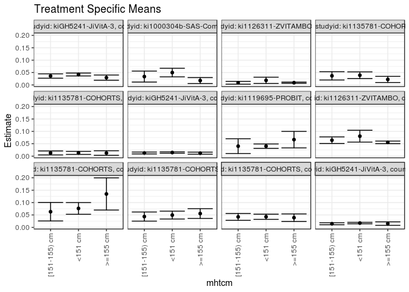

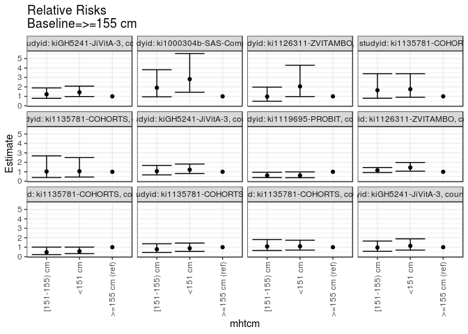

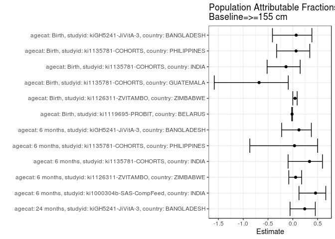

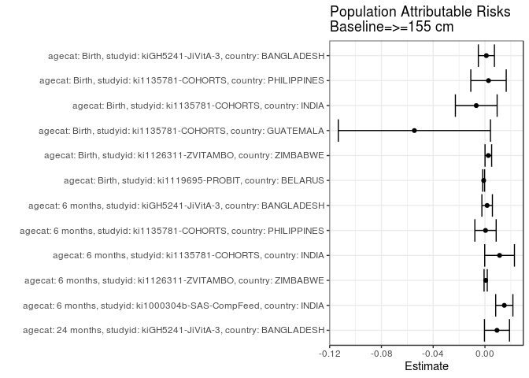

## Results Table

### Parameter: TSM

| agecat | studyid | country | intervention_level | baseline_level | estimate | ci_lower | ci_upper |
| --- | --- | --- | --- | --- | --- | --- | --- |
| Birth | ki1119695-PROBIT | BELARUS | >=155 cm | NA | 0.0666210 | 0.0333280 | 0.0999141 |
| Birth | ki1119695-PROBIT | BELARUS | <151 cm | NA | 0.0403226 | 0.0314227 | 0.0492225 |
| Birth | ki1119695-PROBIT | BELARUS | [151-155) cm | NA | 0.0403023 | 0.0103909 | 0.0702137 |
| Birth | ki1126311-ZVITAMBO | ZIMBABWE | >=155 cm | NA | 0.0555566 | 0.0502864 | 0.0608268 |
| Birth | ki1126311-ZVITAMBO | ZIMBABWE | <151 cm | NA | 0.0805910 | 0.0567094 | 0.1044726 |
| Birth | ki1126311-ZVITAMBO | ZIMBABWE | [151-155) cm | NA | 0.0643986 | 0.0510676 | 0.0777296 |
| Birth | ki1135781-COHORTS | GUATEMALA | >=155 cm | NA | 0.1347467 | 0.0697791 | 0.1997142 |
| Birth | ki1135781-COHORTS | GUATEMALA | <151 cm | NA | 0.0764208 | 0.0527374 | 0.1001043 |
| Birth | ki1135781-COHORTS | GUATEMALA | [151-155) cm | NA | 0.0631280 | 0.0257250 | 0.1005309 |
| Birth | ki1135781-COHORTS | INDIA | >=155 cm | NA | 0.0556458 | 0.0358726 | 0.0754190 |
| Birth | ki1135781-COHORTS | INDIA | <151 cm | NA | 0.0495332 | 0.0336454 | 0.0654210 |
| Birth | ki1135781-COHORTS | INDIA | [151-155) cm | NA | 0.0435056 | 0.0250630 | 0.0619482 |
| Birth | ki1135781-COHORTS | PHILIPPINES | >=155 cm | NA | 0.0389879 | 0.0237152 | 0.0542607 |
| Birth | ki1135781-COHORTS | PHILIPPINES | <151 cm | NA | 0.0427131 | 0.0322602 | 0.0531660 |
| Birth | ki1135781-COHORTS | PHILIPPINES | [151-155) cm | NA | 0.0421865 | 0.0284049 | 0.0559680 |
| Birth | kiGH5241-JiVitA-3 | BANGLADESH | >=155 cm | NA | 0.0150666 | 0.0080342 | 0.0220991 |
| Birth | kiGH5241-JiVitA-3 | BANGLADESH | <151 cm | NA | 0.0172157 | 0.0142467 | 0.0201847 |
| Birth | kiGH5241-JiVitA-3 | BANGLADESH | [151-155) cm | NA | 0.0145189 | 0.0104569 | 0.0185808 |
| 6 months | ki1000304b-SAS-CompFeed | INDIA | >=155 cm | NA | 0.0176817 | 0.0055394 | 0.0298241 |
| 6 months | ki1000304b-SAS-CompFeed | INDIA | <151 cm | NA | 0.0498812 | 0.0325212 | 0.0672413 |
| 6 months | ki1000304b-SAS-CompFeed | INDIA | [151-155) cm | NA | 0.0337838 | 0.0116352 | 0.0559323 |
| 6 months | ki1126311-ZVITAMBO | ZIMBABWE | >=155 cm | NA | 0.0090265 | 0.0065602 | 0.0114929 |
| 6 months | ki1126311-ZVITAMBO | ZIMBABWE | <151 cm | NA | 0.0185185 | 0.0058046 | 0.0312325 |
| 6 months | ki1126311-ZVITAMBO | ZIMBABWE | [151-155) cm | NA | 0.0088149 | 0.0030810 | 0.0145488 |
| 6 months | ki1135781-COHORTS | INDIA | >=155 cm | NA | 0.0222366 | 0.0097679 | 0.0347054 |
| 6 months | ki1135781-COHORTS | INDIA | <151 cm | NA | 0.0391290 | 0.0255739 | 0.0526842 |
| 6 months | ki1135781-COHORTS | INDIA | [151-155) cm | NA | 0.0366855 | 0.0199247 | 0.0534463 |
| 6 months | ki1135781-COHORTS | PHILIPPINES | >=155 cm | NA | 0.0125000 | 0.0032964 | 0.0217036 |
| 6 months | ki1135781-COHORTS | PHILIPPINES | <151 cm | NA | 0.0131579 | 0.0071184 | 0.0191974 |
| 6 months | ki1135781-COHORTS | PHILIPPINES | [151-155) cm | NA | 0.0128535 | 0.0049369 | 0.0207701 |
| 6 months | kiGH5241-JiVitA-3 | BANGLADESH | >=155 cm | NA | 0.0119921 | 0.0078291 | 0.0161551 |
| 6 months | kiGH5241-JiVitA-3 | BANGLADESH | <151 cm | NA | 0.0145786 | 0.0116892 | 0.0174679 |
| 6 months | kiGH5241-JiVitA-3 | BANGLADESH | [151-155) cm | NA | 0.0126829 | 0.0088600 | 0.0165059 |
| 24 months | kiGH5241-JiVitA-3 | BANGLADESH | >=155 cm | NA | 0.0294401 | 0.0190089 | 0.0398712 |
| 24 months | kiGH5241-JiVitA-3 | BANGLADESH | <151 cm | NA | 0.0421630 | 0.0363330 | 0.0479931 |
| 24 months | kiGH5241-JiVitA-3 | BANGLADESH | [151-155) cm | NA | 0.0359983 | 0.0273277 | 0.0446689 |

### Parameter: E(Y)

| agecat | studyid | country | intervention_level | baseline_level | estimate | ci_lower | ci_upper |
| --- | --- | --- | --- | --- | --- | --- | --- |
| Birth | ki1119695-PROBIT | BELARUS | NA | NA | 0.0656181 | 0.0328425 | 0.0983937 |
| Birth | ki1126311-ZVITAMBO | ZIMBABWE | NA | NA | 0.0581742 | 0.0533538 | 0.0629946 |
| Birth | ki1135781-COHORTS | GUATEMALA | NA | NA | 0.0802139 | 0.0607354 | 0.0996924 |
| Birth | ki1135781-COHORTS | INDIA | NA | NA | 0.0489260 | 0.0385956 | 0.0592564 |
| Birth | ki1135781-COHORTS | PHILIPPINES | NA | NA | 0.0417385 | 0.0344572 | 0.0490198 |
| Birth | kiGH5241-JiVitA-3 | BANGLADESH | NA | NA | 0.0161682 | 0.0137981 | 0.0185383 |
| 6 months | ki1000304b-SAS-CompFeed | INDIA | NA | NA | 0.0326264 | 0.0237765 | 0.0414763 |
| 6 months | ki1126311-ZVITAMBO | ZIMBABWE | NA | NA | 0.0095734 | 0.0073088 | 0.0118381 |
| 6 months | ki1135781-COHORTS | INDIA | NA | NA | 0.0335349 | 0.0252594 | 0.0418104 |
| 6 months | ki1135781-COHORTS | PHILIPPINES | NA | NA | 0.0129342 | 0.0086762 | 0.0171922 |
| 6 months | kiGH5241-JiVitA-3 | BANGLADESH | NA | NA | 0.0136847 | 0.0116040 | 0.0157654 |
| 24 months | kiGH5241-JiVitA-3 | BANGLADESH | NA | NA | 0.0387398 | 0.0343960 | 0.0430836 |

### Parameter: RR

| agecat | studyid | country | intervention_level | baseline_level | estimate | ci_lower | ci_upper |
| --- | --- | --- | --- | --- | --- | --- | --- |
| Birth | ki1119695-PROBIT | BELARUS | >=155 cm | >=155 cm | 1.0000000 | 1.0000000 | 1.0000000 |
| Birth | ki1119695-PROBIT | BELARUS | <151 cm | >=155 cm | 0.6052531 | 0.3706026 | 0.9884746 |
| Birth | ki1119695-PROBIT | BELARUS | [151-155) cm | >=155 cm | 0.6049481 | 0.3856235 | 0.9490143 |
| Birth | ki1126311-ZVITAMBO | ZIMBABWE | >=155 cm | >=155 cm | 1.0000000 | 1.0000000 | 1.0000000 |
| Birth | ki1126311-ZVITAMBO | ZIMBABWE | <151 cm | >=155 cm | 1.4506110 | 1.0627096 | 1.9801010 |
| Birth | ki1126311-ZVITAMBO | ZIMBABWE | [151-155) cm | >=155 cm | 1.1591529 | 0.9231030 | 1.4555641 |
| Birth | ki1135781-COHORTS | GUATEMALA | >=155 cm | >=155 cm | 1.0000000 | 1.0000000 | 1.0000000 |
| Birth | ki1135781-COHORTS | GUATEMALA | <151 cm | >=155 cm | 0.5671444 | 0.3197404 | 1.0059812 |
| Birth | ki1135781-COHORTS | GUATEMALA | [151-155) cm | >=155 cm | 0.4684940 | 0.2182298 | 1.0057592 |
| Birth | ki1135781-COHORTS | INDIA | >=155 cm | >=155 cm | 1.0000000 | 1.0000000 | 1.0000000 |
| Birth | ki1135781-COHORTS | INDIA | <151 cm | >=155 cm | 0.8901511 | 0.5514138 | 1.4369770 |
| Birth | ki1135781-COHORTS | INDIA | [151-155) cm | >=155 cm | 0.7818307 | 0.4495752 | 1.3596373 |
| Birth | ki1135781-COHORTS | PHILIPPINES | >=155 cm | >=155 cm | 1.0000000 | 1.0000000 | 1.0000000 |
| Birth | ki1135781-COHORTS | PHILIPPINES | <151 cm | >=155 cm | 1.0955472 | 0.6903804 | 1.7384960 |
| Birth | ki1135781-COHORTS | PHILIPPINES | [151-155) cm | >=155 cm | 1.0820390 | 0.6497302 | 1.8019915 |
| Birth | kiGH5241-JiVitA-3 | BANGLADESH | >=155 cm | >=155 cm | 1.0000000 | 1.0000000 | 1.0000000 |
| Birth | kiGH5241-JiVitA-3 | BANGLADESH | <151 cm | >=155 cm | 1.1426375 | 0.6933288 | 1.8831187 |
| Birth | kiGH5241-JiVitA-3 | BANGLADESH | [151-155) cm | >=155 cm | 0.9636440 | 0.5623384 | 1.6513360 |
| 6 months | ki1000304b-SAS-CompFeed | INDIA | >=155 cm | >=155 cm | 1.0000000 | 1.0000000 | 1.0000000 |
| 6 months | ki1000304b-SAS-CompFeed | INDIA | <151 cm | >=155 cm | 2.8210609 | 1.4369308 | 5.5384603 |
| 6 months | ki1000304b-SAS-CompFeed | INDIA | [151-155) cm | >=155 cm | 1.9106606 | 0.9555150 | 3.8205826 |
| 6 months | ki1126311-ZVITAMBO | ZIMBABWE | >=155 cm | >=155 cm | 1.0000000 | 1.0000000 | 1.0000000 |
| 6 months | ki1126311-ZVITAMBO | ZIMBABWE | <151 cm | >=155 cm | 2.0515614 | 0.9798815 | 4.2953193 |
| 6 months | ki1126311-ZVITAMBO | ZIMBABWE | [151-155) cm | >=155 cm | 0.9765512 | 0.4822644 | 1.9774471 |
| 6 months | ki1135781-COHORTS | INDIA | >=155 cm | >=155 cm | 1.0000000 | 1.0000000 | 1.0000000 |
| 6 months | ki1135781-COHORTS | INDIA | <151 cm | >=155 cm | 1.7596668 | 0.9102846 | 3.4016035 |
| 6 months | ki1135781-COHORTS | INDIA | [151-155) cm | >=155 cm | 1.6497782 | 0.8004193 | 3.4004278 |
| 6 months | ki1135781-COHORTS | PHILIPPINES | >=155 cm | >=155 cm | 1.0000000 | 1.0000000 | 1.0000000 |
| 6 months | ki1135781-COHORTS | PHILIPPINES | <151 cm | >=155 cm | 1.0526316 | 0.4420422 | 2.5066230 |
| 6 months | ki1135781-COHORTS | PHILIPPINES | [151-155) cm | >=155 cm | 1.0282776 | 0.3937471 | 2.6853657 |
| 6 months | kiGH5241-JiVitA-3 | BANGLADESH | >=155 cm | >=155 cm | 1.0000000 | 1.0000000 | 1.0000000 |
| 6 months | kiGH5241-JiVitA-3 | BANGLADESH | <151 cm | >=155 cm | 1.2156785 | 0.8109889 | 1.8223113 |
| 6 months | kiGH5241-JiVitA-3 | BANGLADESH | [151-155) cm | >=155 cm | 1.0576064 | 0.6679246 | 1.6746372 |
| 24 months | kiGH5241-JiVitA-3 | BANGLADESH | >=155 cm | >=155 cm | 1.0000000 | 1.0000000 | 1.0000000 |
| 24 months | kiGH5241-JiVitA-3 | BANGLADESH | <151 cm | >=155 cm | 1.4321650 | 0.9845386 | 2.0833075 |
| 24 months | kiGH5241-JiVitA-3 | BANGLADESH | [151-155) cm | >=155 cm | 1.2227647 | 0.7894477 | 1.8939236 |

### Parameter: PAR

| agecat | studyid | country | intervention_level | baseline_level | estimate | ci_lower | ci_upper |
| --- | --- | --- | --- | --- | --- | --- | --- |
| Birth | ki1119695-PROBIT | BELARUS | >=155 cm | NA | -0.0010029 | -0.0017368 | -0.0002690 |
| Birth | ki1126311-ZVITAMBO | ZIMBABWE | >=155 cm | NA | 0.0026176 | 0.0000641 | 0.0051711 |
| Birth | ki1135781-COHORTS | GUATEMALA | >=155 cm | NA | -0.0545327 | -0.1133330 | 0.0042675 |
| Birth | ki1135781-COHORTS | INDIA | >=155 cm | NA | -0.0067198 | -0.0228461 | 0.0094064 |
| Birth | ki1135781-COHORTS | PHILIPPINES | >=155 cm | NA | 0.0027506 | -0.0109289 | 0.0164301 |
| Birth | kiGH5241-JiVitA-3 | BANGLADESH | >=155 cm | NA | 0.0011016 | -0.0051176 | 0.0073207 |
| 6 months | ki1000304b-SAS-CompFeed | INDIA | >=155 cm | NA | 0.0149447 | 0.0082992 | 0.0215902 |
| 6 months | ki1126311-ZVITAMBO | ZIMBABWE | >=155 cm | NA | 0.0005469 | -0.0006919 | 0.0017857 |
| 6 months | ki1135781-COHORTS | INDIA | >=155 cm | NA | 0.0112983 | -0.0001867 | 0.0227833 |
| 6 months | ki1135781-COHORTS | PHILIPPINES | >=155 cm | NA | 0.0004342 | -0.0077985 | 0.0086669 |
| 6 months | kiGH5241-JiVitA-3 | BANGLADESH | >=155 cm | NA | 0.0016926 | -0.0023741 | 0.0057593 |
| 24 months | kiGH5241-JiVitA-3 | BANGLADESH | >=155 cm | NA | 0.0092997 | -0.0003740 | 0.0189735 |

### Parameter: PAF

| agecat | studyid | country | intervention_level | baseline_level | estimate | ci_lower | ci_upper |
| --- | --- | --- | --- | --- | --- | --- | --- |
| Birth | ki1119695-PROBIT | BELARUS | >=155 cm | NA | -0.0152838 | -0.0233119 | -0.0073186 |
| Birth | ki1126311-ZVITAMBO | ZIMBABWE | >=155 cm | NA | 0.0449957 | 0.0002259 | 0.0877607 |
| Birth | ki1135781-COHORTS | GUATEMALA | >=155 cm | NA | -0.6798416 | -1.5847743 | -0.0917270 |
| Birth | ki1135781-COHORTS | INDIA | >=155 cm | NA | -0.1373466 | -0.5185680 | 0.1481730 |
| Birth | ki1135781-COHORTS | PHILIPPINES | >=155 cm | NA | 0.0659008 | -0.3264195 | 0.3421830 |
| Birth | kiGH5241-JiVitA-3 | BANGLADESH | >=155 cm | NA | 0.0681311 | -0.4108925 | 0.3845176 |
| 6 months | ki1000304b-SAS-CompFeed | INDIA | >=155 cm | NA | 0.4580550 | 0.1241974 | 0.6646454 |
| 6 months | ki1126311-ZVITAMBO | ZIMBABWE | >=155 cm | NA | 0.0571239 | -0.0807771 | 0.1774295 |
| 6 months | ki1135781-COHORTS | INDIA | >=155 cm | NA | 0.3369112 | -0.0952974 | 0.5985686 |
| 6 months | ki1135781-COHORTS | PHILIPPINES | >=155 cm | NA | 0.0335714 | -0.8670734 | 0.4997603 |
| 6 months | kiGH5241-JiVitA-3 | BANGLADESH | >=155 cm | NA | 0.1236847 | -0.2253915 | 0.3733198 |
| 24 months | kiGH5241-JiVitA-3 | BANGLADESH | >=155 cm | NA | 0.2400563 | -0.0559647 | 0.4530931 |